# N back performance metrics and subjective fatigue metric

- N-back performance
  - Load python modules
  - Import data
  - Calculate performance metrics
    - Practice runs
    - Test runs
  - Analyze performance metrics of 2-back
    - Accuracy, sensitivity and specificity
    - Reaction times
- Subjective fatigue metric
  - Calculate subjective fatigue metric
  - Analyze subjective fatigue metric

## N-back performance

### Load python modules

```python
import pandas as pd
import matplotlib.pyplot as plt
import numpy as np
import researchpy as rp
import statsmodels.api as sm
import scipy.stats as stats
from statsmodels.formula.api import mixedlm
from statsmodels.stats.diagnostic import het_white
import dataframe_image as dfi
#from stat_lmm_utils import plot_lmm_oneslope_randintercept
```

#### Define functions

```python
def csv_to_xlsx(directory, filename):

    # Fix directory if needed
    directory = directory.replace('\\', '/')

    # Add backslash
    directory += '/'

    # Read the csv file into Dataframe
    df = pd.read_csv(directory + filename + '.csv')

    # Convert the .csv file to .xlsx file and save
    df.to_excel(directory + filename + '.xlsx', index=False) # sheet_name="Test"

def xlsx_to_df(directory, filename):

    # Fix directory if needed
    directory = directory.replace('\\', '/')

    # Add backslash
    directory += '/'

    # Return data frame
    return pd.read_excel(directory + filename + '.xlsx')

def find_sens_spec(errors):
    """
    Input: list(TP, FP, FN, TN)
    Output: tuple(sensitivity, specificity)
    """
    if (errors[0] + errors[2] != 0) and (errors[3] + errors[1] != 0):
        sens = errors[0]/(errors[0] + errors[2])
        spec = errors[3]/(errors[3] + errors[1])
        return round(sens,3), round(spec,3)
    else:
        alert = 'Can not devide through zero'
        return alert

def find_error_types(df, id_start, id_stop, key_name):
    """
    Input: start index, stop index, column key name
    Output: list(TP, FP, FN, TN)
    """

    # TP
    condition1 = df[key_name][id_start:id_stop] == 'space'
    condition2 = df['CorrAns'][id_start:id_stop] == 'space'

    combined_condition = np.logical_and(condition1, condition2)

    TP = np.sum(np.where(combined_condition, 1, 0))

    # FP
    condition3 = df[key_name][id_start:id_stop] == 'space'
    condition4 = df['CorrAns'][id_start:id_stop] != 'space'

    combined_condition2 = np.logical_and(condition3, condition4)

    FP = np.sum(np.where(combined_condition2, 1, 0))

    # FN
    condition5 = df[key_name][id_start:id_stop] != 'space'
    condition6 = df['CorrAns'][id_start:id_stop] == 'space'

    combined_condition3 = np.logical_and(condition5, condition6)

    FN = np.sum(np.where(combined_condition3, 1, 0))

    # TN
    condition7 = df[key_name][id_start:id_stop] != 'space'
    condition8 = df['CorrAns'][id_start:id_stop] != 'space'

    combined_condition4 = np.logical_and(condition7, condition8)

    TN = np.sum(np.where(combined_condition4, 1, 0))

    return [TP, FP, FN, TN]

def find_rt(df, key_name, key_name_rt, id_start, id_stop):
    condition1 = df[key_name][id_start:id_stop] == 'space'
    condition2 = df['CorrAns'][id_start:id_stop] == 'space'
    condition3 = df['CorrAns'][id_start:id_stop] != 'space'

    combined_condition = np.logical_and(condition1, condition2)
    combined_condition2 = np.logical_and(condition1, condition3)

    rts = df[key_name_rt][id_start:id_stop].to_numpy()

    rts_correct = rts[np.where(combined_condition)[0]]
    rts_not_correct = rts[np.where(combined_condition2)[0]]

    if len(rts) > 0:
        mean_rts = np.nanmean(rts)
    else:
        mean_rts = np.nan
    if len(rts_correct) > 0:
        mean_rts_correct = np.nanmean(rts_correct)
    else:
        mean_rts_correct = np.nan
    if len(rts_not_correct) > 0:
        mean_rts_not_correct = np.nanmean(rts_not_correct)
    else:
        mean_rts_not_correct = np.nan

    return np.array([round(mean_rts,3), round(mean_rts_correct,3),round(mean_rts_not_correct,3)])

def get_LME_data(df, subjects = ['A', 'B', 'C', 'D']):
    metrics = []
    for subject in subjects:
        df_subject = df[df['Subject'] == subject]
        for block, (start, end) in enumerate([(113, 513), (514, 914), (915, 1315)], start=1):
            accuracy =  (sum(df_subject['key_resp_6.corr'][start:end])/len(df_subject['key_resp_6.corr'][start:end]))*100
            sensitivity = 100*find_sens_spec(find_error_types(df_subject, start, end, 'key_resp_6.keys'))[0]
            specificity = 100*find_sens_spec(find_error_types(df_subject, start, end, 'key_resp_6.keys'))[1]
            metrics.append([subject, block, accuracy, sensitivity, specificity])

    df_metrics = pd.DataFrame(metrics, columns=['Subject', 'Block', 'Accuracy', 'Sensitivity', 'Specificity'])

    return df_metrics




def get_LME_data2(df, subjects = ['A', 'B', 'C', 'D']):
    metrics = []
    for subject in subjects:
        df_subject = df[df['Subject'] == subject]
        for block, (start, end) in enumerate([(113, 513), (514, 914), (915, 1315)], start=1):
            rt_mean =  find_rt(df_subject, 'key_resp_6.keys', 'key_resp_6.rt', start, end)[0]
            rt_mean_correct =  find_rt(df_subject, 'key_resp_6.keys', 'key_resp_6.rt', start, end)[1]
            rt_mean_uncorrect =  find_rt(df_subject, 'key_resp_6.keys', 'key_resp_6.rt', start, end)[2]
            metrics.append([subject, block, rt_mean, rt_mean_correct, rt_mean_uncorrect])

    df_metrics = pd.DataFrame(metrics, columns=['Subject', 'Block', 'RT_all', 'RT_correct', 'RT_uncorrect'])

    return df_metrics

def get_LME_data3(df, subjects = ['A', 'B', 'C', 'D']):
    metrics = []
    for subject in subjects:
        df_subject = df[df['Subject'] == subject]
        metrics.append([subject, 0, df_subject['slider_2.response'][112]])
        for block, id in enumerate([513, 914, 1315], start=1):
            score =  df_subject['slider.response'][id]
            metrics.append([subject, block, score])

    df_metrics = pd.DataFrame(metrics, columns=['Subject', 'Block', 'Score'])

    return df_metrics
```

### Import data

##### Convert csv in to xlsx

```python
# directory = r'D:\Unif\Madrid 2023-2024\thesis\DATA cortivision\20240426'
# filename = '5_N-back_2024-04-26_13h43.45.018'

# csv_to_xlsx(directory, filename)
```

##### Convert xslx to dataframe

```python
# Better for analysis
# Rocco
directoryA = r'D:\Unif\Madrid 2023-2024\thesis\DATA cortivision\20240426'
filenameA = '5_N-back_2024-04-26_13h43.45.018'

dfA =  xlsx_to_df(directoryA, filenameA)

# Tamara
directoryB = r'D:\Unif\Madrid 2023-2024\thesis\DATA cortivision\20240430'
filenameB = '7_N-back_2024-04-30_15h11.47.453'

dfB =  xlsx_to_df(directoryB, filenameB)

# Justine
directoryC = r'D:\Unif\Madrid 2023-2024\thesis\DATA cortivision\20240412'
filenameC = 'justine_fully_corrected'

dfC =  xlsx_to_df(directoryC, filenameC)

# Frank
directoryD = r'D:\Unif\Madrid 2023-2024\thesis\DATA cortivision\20240429'
filenameD = '6_N-back_2024-04-29_13h36.49.144'

dfD =  xlsx_to_df(directoryD, filenameD)
```

```python
subjects = ['1', '2', '3', '4']
dfA['Subject'] = '1'
dfB['Subject'] = '2'
dfC['Subject'] = '3'
dfD['Subject'] = '4'
df = pd.concat([dfA, dfB, dfC, dfD])
df.head(5)
```

|  | Letter1 | Target | CorrAns | Letter2 | thisCond | Msg | thisSurvey | trials_4.thisRepN | trials_4.thisTrialN | trials_4.thisN | ... | key_resp_20.keys_org | key_resp_20.stopped | text_18.stopped | key_resp_6.keys_org | key_resp_6.stopped | Unnamed: 211 | Unnamed: 212 | Unnamed: 213 | Unnamed: 214 | Unnamed: 216 |
| --- | --- | --- | --- | --- | --- | --- | --- | --- | --- | --- | --- | --- | --- | --- | --- | --- | --- | --- | --- | --- | --- |
| 0 | NaN | NaN | NaN | NaN | NaN | NaN | NaN | NaN | NaN | NaN | ... | NaN | NaN | NaN | NaN | NaN | NaN | NaN | NaN | NaN | NaN |
| 1 | NaN | NaN | NaN | NaN | NaN | NaN | NaN | NaN | NaN | NaN | ... | NaN | NaN | NaN | NaN | NaN | NaN | NaN | NaN | NaN | NaN |
| 2 | NaN | NaN | NaN | NaN | NaN | NaN | NaN | NaN | NaN | NaN | ... | NaN | NaN | NaN | NaN | NaN | NaN | NaN | NaN | NaN | NaN |
| 3 | NaN | NaN | NaN | NaN | NaN | NaN | NaN | NaN | NaN | NaN | ... | NaN | NaN | NaN | NaN | NaN | NaN | NaN | NaN | NaN | NaN |
| 4 | E | 0.0 | None | NaN | NaN | NaN | NaN | 0.0 | 0.0 | 0.0 | ... | NaN | NaN | NaN | NaN | NaN | NaN | NaN | NaN | NaN | NaN |

5 rows × 221 columns

```python
# Export figures?
export = True
```

### Calculate performance metrics

### Practice runs

#### 0 Back

##### Accuracy

```python
acc_p0 = np.zeros(4)
for i, subject in enumerate(subjects):
    df_subject = df[df['Subject'] == subject]
    acc_p0[i] = (sum(df_subject['key_resp_16.corr'][4:14])/len(df_subject['key_resp_16.corr'][4:14]))*100
```

```python
print('The accuracy of the practice 0 back test is: ' + str(acc_p0) + ' %')
```

```
The accuracy of the practice 0 back test is: [ 90. 100. 100. 100.] %
```

*Remark:*

- Participant understood the assignment

#### 2 Back

##### Accuracy

```python
acc_p2 = np.zeros(4)
for i, subject in enumerate(subjects):
    df_subject = df[df['Subject'] == subject]
    acc_p2[i] = (sum(df_subject['key_resp_4.corr'][16:26])/len(df_subject['key_resp_4.corr'][16:26]))*100
```

```python
print('The accuracy of the practice 2 back test is: ' + str(acc_p2) + ' %')
```

```
The accuracy of the practice 2 back test is: [100.  90.  90. 100.] %
```

*Remark:*

- Participant understood the assignment

### Test runs

#### 0 Back

##### Accuracy

```python
acc_t0 = np.zeros(4)
for i, subject in enumerate(subjects):
    df_subject = df[df['Subject'] == subject]
    acc_t0[i] = (sum(df_subject['key_resp_20.corr'][70:110])/len(df_subject['key_resp_20.corr'][70:110]))*100
```

```python
print('The accuracy of the 0 back test is: ' + str(acc_t0) + ' %')
```

```
The accuracy of the 0 back test is: [100. 100. 100. 100.] %
```

*Remark:*

- Participant understood the assignment

##### Reaction times

[output not shown]

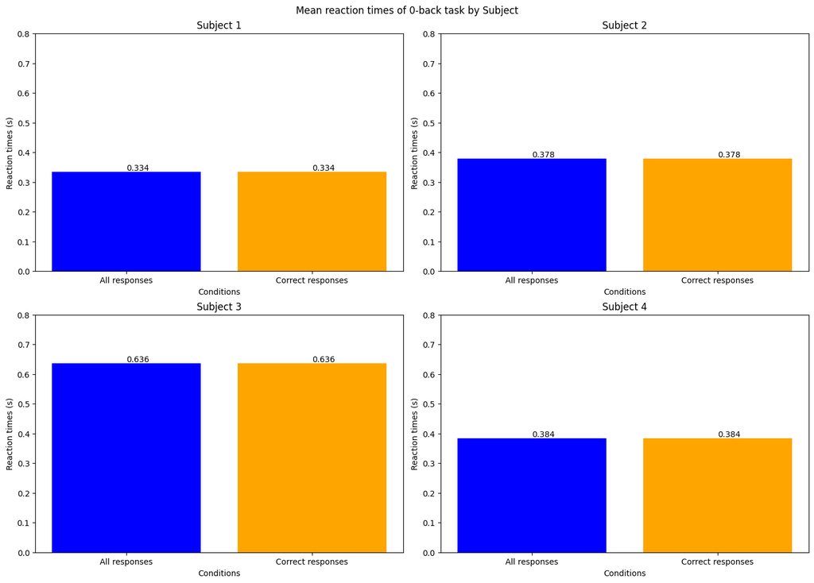

```python
rt_0_back = np.zeros((4,3))
for i, subject in enumerate(subjects):
    df_subject = df[df['Subject'] == subject]
    rt_0_back[i] = find_rt(df_subject, 'key_resp_20.keys', 'key_resp_20.rt', 70, 110)


fig, axs = plt.subplots(2, 2, figsize=(14, 10), constrained_layout=True)
fig.suptitle('Mean reaction times of 0-back task by Subject')

labels = ['All responses', 'Correct responses', 'Uncorrect responses']
colors = ['blue', 'orange', 'green']

for i, (subject, ax) in enumerate(zip(subjects, axs.flat)):
    values = rt_0_back[i]
    bars = ax.bar(labels, values, color=colors)

    ax.set_ylabel('Reaction times (s)')
    ax.set_xlabel('Conditions')
    ax.set_title('Subject ' + subject)
    ax.set_ylim(0, 0.8)

    for bar in bars:
        yval = bar.get_height()
        ax.text(bar.get_x() + bar.get_width()/2.0, yval, round(yval, 3), va='bottom')

plt.show()
```

```python
# Order of blocks
block_order = list(np.zeros((4,3)))
for i, subject in enumerate(subjects):
    df_subject = df[df['Subject'] == subject]
    block_order[i] = [df_subject['Msg'][113][-1], df_subject['Msg'][514][-1], df_subject['Msg'][915][-1]]
print('The order of the blocks is: ' + str(block_order))
```

```
The order of the blocks is: [['a', 'c', 'b'], ['c', 'b', 'a'], ['b', 'c', 'a'], ['a', 'c', 'b']]
```

#### 2-back

##### Accuracy, sensitivity and specificity

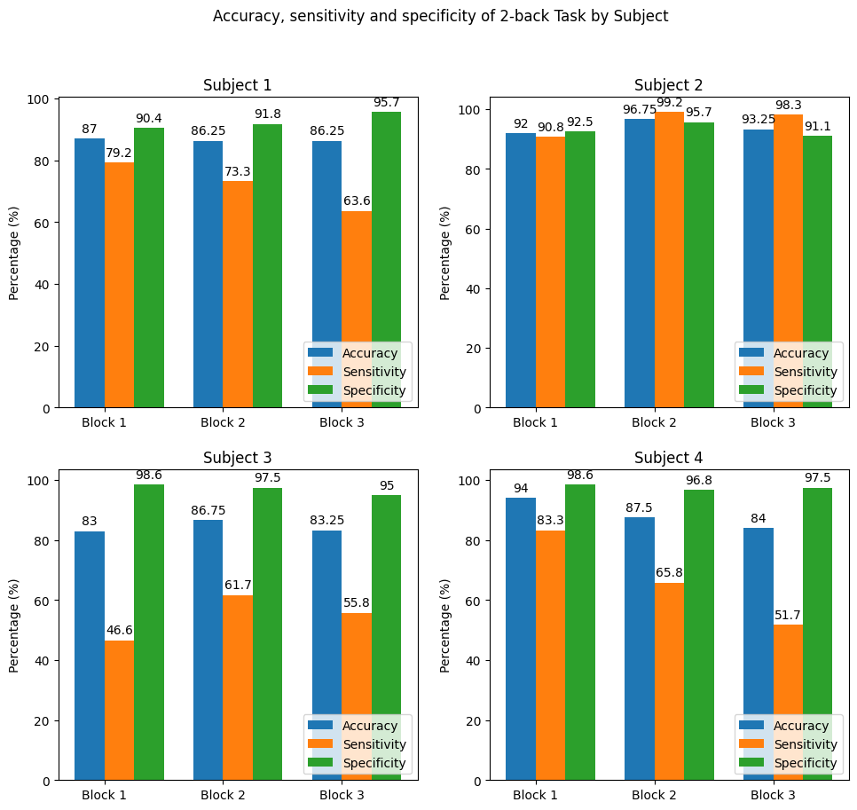

```python
Blocks = ("Block 1", "Block 2", "Block 3")

acc_sens_spec = []
for i, subject in enumerate(subjects):
    df_subject = df[df['Subject'] == subject]
    acc_sens_spec.append({
        'Accuracy': (
            (sum(df_subject['key_resp_6.corr'][113:513])/len(df_subject['key_resp_6.corr'][113:513]))*100,
            (sum(df_subject['key_resp_6.corr'][514:914])/len(df_subject['key_resp_6.corr'][514:914]))*100,
            (sum(df_subject['key_resp_6.corr'][915:1315])/len(df_subject['key_resp_6.corr'][915:1315]))*100
        ),
        'Sensitivity': (
            100*find_sens_spec(find_error_types(df_subject, 113, 513, 'key_resp_6.keys'))[0],
            100*find_sens_spec(find_error_types(df_subject, 514, 914, 'key_resp_6.keys'))[0],
            100*find_sens_spec(find_error_types(df_subject, 915, 1315, 'key_resp_6.keys'))[0]
        ),
        'Specificity': (
            100*find_sens_spec(find_error_types(df_subject, 113, 513, 'key_resp_6.keys'))[1],
            100*find_sens_spec(find_error_types(df_subject, 514, 914, 'key_resp_6.keys'))[1],
            100*find_sens_spec(find_error_types(df_subject, 915, 1315, 'key_resp_6.keys'))[1]
        ),
    })

x = np.arange(len(Blocks))
width = 0.25

fig, axs = plt.subplots(2, 2, figsize=(11.5, 10))
fig.suptitle('Accuracy, sensitivity and specificity of 2-back Task by Subject')

for i, (subject, ax) in enumerate(zip(subjects, axs.flat)):
    multiplier = 0
    for attribute, measurement in acc_sens_spec[i].items():
        offset = width * multiplier
        rects = ax.bar(x + offset, measurement, width, label=attribute)
        ax.bar_label(rects, padding=3)
        multiplier += 1

    ax.set_ylabel('Percentage (%)')
    ax.set_title('Subject ' + subject)
    ax.set_xticks(x + width / 2, Blocks)
    ax.legend(loc='lower right')

plt.show()
```

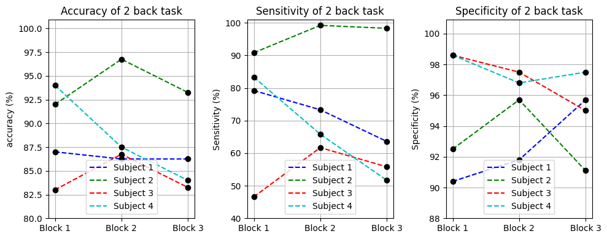

```python
x = ['Block 1', 'Block 2', 'Block 3']
colors = ['b', 'g', 'r', 'c']

fig, (ax1, ax2, ax3) = plt.subplots(1, 3, figsize=(10, 4))

# Accuracy plot
for i, subject in enumerate(subjects):
    ax1.plot(x, acc_sens_spec[i]['Accuracy'], '--', color=colors[i], label='Subject ' + subject)
    ax1.plot(x, acc_sens_spec[i]['Accuracy'], 'o', color='k')

ax1.set_ylim(80, 100.9)
ax1.set_ylabel('accuracy (%)')
ax1.grid(visible=True)
ax1.set_title('Accuracy of 2 back task')
ax1.legend(loc='lower center')

# Sensitivity plot
for i, subject in enumerate(subjects):
    ax2.plot(x, acc_sens_spec[i]['Sensitivity'], '--', color=colors[i], label='Subject ' + subject)
    ax2.plot(x, acc_sens_spec[i]['Sensitivity'], 'o', color='k')

ax2.set_ylim(40, 100.9)
ax2.set_ylabel('Sensitivity (%)')
ax2.grid(visible=True)
ax2.set_title('Sensitivity of 2 back task')
ax2.legend()

# Specificity plot
for i, subject in enumerate(subjects):
    ax3.plot(x, acc_sens_spec[i]['Specificity'], '--', color=colors[i], label='Subject ' + subject)
    ax3.plot(x, acc_sens_spec[i]['Specificity'], 'o', color='k')

ax3.set_ylim(88, 100.9)
ax3.set_ylabel('Specificity (%)')
ax3.grid(visible=True)
ax3.set_title('Specificity of 2 back task')
ax3.legend()

plt.tight_layout()
if export:
    plt.savefig('acc_sens_spec.png')
plt.show()
```

*Remark:*

- No clear conclusion can be drawn
- Use statistical metrics to define if there is a change in accuracy, sensitivity or specificity

##### Error rate

```python
err_t2 = []
for i, subject in enumerate(subjects):
    df_subject = df[df['Subject'] == subject]
    err_t2_1 = np.where(df_subject['key_resp_6.corr'][113:513] == 0, 1, 0)
    err_t2_2 = np.where(df_subject['key_resp_6.corr'][514:914] == 0, 1, 0)
    err_t2_3 = np.where(df_subject['key_resp_6.corr'][915:1315] == 0, 1, 0)
    err_t2.append([err_t2_1, err_t2_2, err_t2_3])
err_t2 = np.array(err_t2)
```

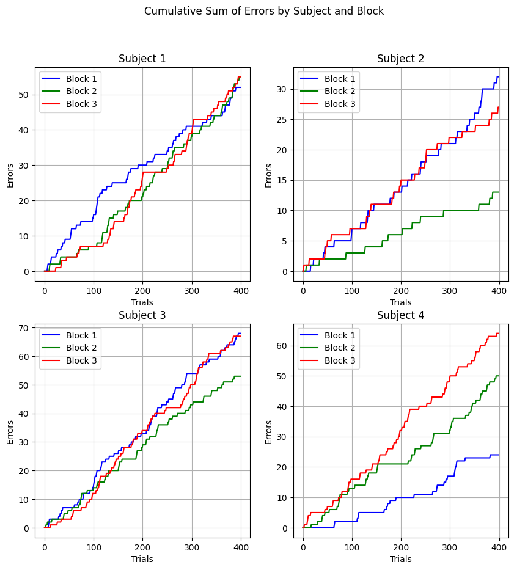

```python
colors = ['b', 'g', 'r']

fig, axs = plt.subplots(2, 2, figsize=(10, 10))
fig.suptitle('Cumulative Sum of Errors by Subject and Block')

for i, subject in enumerate(subjects):
    ax = axs[i // 2, i % 2]
    ax.plot(np.cumsum(err_t2[i, 0]), '-', color=colors[0], label='Block 1')
    ax.plot(np.cumsum(err_t2[i, 1]), '-', color=colors[1], label='Block 2')
    ax.plot(np.cumsum(err_t2[i, 2]), '-', color=colors[2], label='Block 3')

    ax.set_title('Subject ' + subject)
    ax.set_xlabel('Trials')
    ax.set_ylabel('Errors')
    ax.grid(True)
    ax.legend()

plt.show()
```

*Remark:*

- Visually no evolution during blocks

##### Reaction times

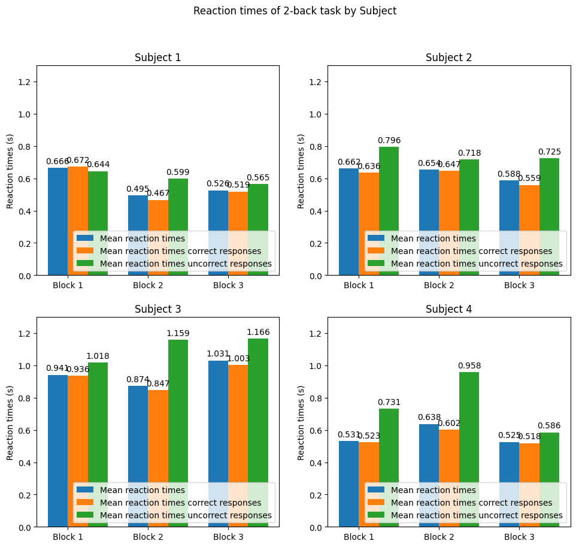

```python
# Plot

mean_rts = []
for i, subject in enumerate(subjects):
    df_subject = df[df['Subject'] == subject]
    mean_rts.append({
        'Mean reaction times': (
            find_rt(df_subject, 'key_resp_6.keys', 'key_resp_6.rt', 113, 513)[0],
            find_rt(df_subject, 'key_resp_6.keys', 'key_resp_6.rt', 514, 914)[0],
            find_rt(df_subject, 'key_resp_6.keys', 'key_resp_6.rt', 915, 1315)[0]
        ),
        'Mean reaction times correct responses': (
            find_rt(df_subject, 'key_resp_6.keys', 'key_resp_6.rt', 113, 513)[1],
            find_rt(df_subject, 'key_resp_6.keys', 'key_resp_6.rt', 514, 914)[1],
            find_rt(df_subject, 'key_resp_6.keys', 'key_resp_6.rt', 915, 1315)[1]
        ),
        'Mean reaction times uncorrect responses': (
            find_rt(df_subject, 'key_resp_6.keys', 'key_resp_6.rt', 113, 513)[2],
            find_rt(df_subject, 'key_resp_6.keys', 'key_resp_6.rt', 514, 914)[2],
            find_rt(df_subject, 'key_resp_6.keys', 'key_resp_6.rt', 915, 1315)[2]
        )
    })

x = np.arange(len(Blocks))
width = 0.25
multiplier = 0

fig, axs = plt.subplots(2, 2, figsize=(11.5, 10))
fig.suptitle('Reaction times of 2-back task by Subject')

for i, (subject, ax) in enumerate(zip(subjects, axs.flat)):
    multiplier = 0
    for attribute, measurement in mean_rts[i].items():
        offset = width * multiplier
        rects = ax.bar(x + offset, measurement, width, label=attribute)
        ax.bar_label(rects, padding=3)
        multiplier += 1

    ax.set_ylabel('Reaction times (s)')
    ax.set_title('Subject ' + subject)
    ax.set_xticks(x + width / 2, Blocks)
    ax.legend(loc='lower right')
    ax.set_ylim(0, 1.3)

plt.show()
```

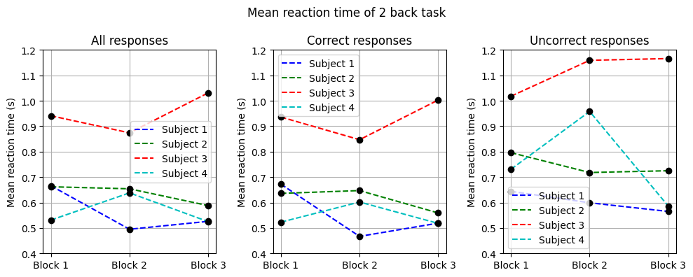

```python
x = ['Block 1', 'Block 2', 'Block 3']
colors = ['b', 'g', 'r', 'c']

fig, (ax1, ax2, ax3) = plt.subplots(1, 3, figsize=(10, 4))
fig.suptitle('Mean reaction time of 2 back task')
for i, subject in enumerate(subjects):
    ax1.plot(x, mean_rts[i]['Mean reaction times'], '--', color=colors[i], label='Subject ' + subject)
    ax1.plot(x, mean_rts[i]['Mean reaction times'], 'o', color='k')

ax1.set_ylim(0.4,1.2)
ax1.set_ylabel('Mean reaction time (s)')
ax1.grid(visible=True)
ax1.set_title('All responses')
ax1.legend()

for i, subject in enumerate(subjects):
    ax2.plot(x, mean_rts[i]['Mean reaction times correct responses'], '--', color=colors[i], label='Subject ' + subject)
    ax2.plot(x, mean_rts[i]['Mean reaction times correct responses'], 'o', color='k')

ax2.set_ylim(0.4,1.2)
ax2.set_ylabel('Mean reaction time (s)')
ax2.grid(visible=True)
ax2.set_title('Correct responses')
ax2.legend()

for i, subject in enumerate(subjects):
    ax3.plot(x, mean_rts[i]['Mean reaction times uncorrect responses'], '--', color=colors[i], label='Subject ' + subject)
    ax3.plot(x, mean_rts[i]['Mean reaction times uncorrect responses'], 'o', color='k')

ax3.set_ylim(0.4,1.2)
ax3.set_ylabel('Mean reaction time (s)')
ax3.grid(visible=True)
ax3.set_title('Uncorrect responses')
ax3.legend()

plt.tight_layout()
if export:
    plt.savefig('reaction_times.png')
plt.show()
```

*Remark:*

- No clear conclusion can be drawn
- Use statistical metrics to define if there is a change in reaction time

### Analyze performance metrics of 2-back

#### Accuracy, sensitivuty and specificity

For each measurement ($y$) the model is: $$ y_{ij} = \beta_0 + \beta_1 \cdot Block_i + u_j^0 + u_j^1 \cdot Block_i + \epsilon_{ij} $$

where:

- $y_{ij}$: The performance metric or self-reported MF level for block $i$ of subject $j$.
- $Block_i$: Indicator variable for the 2-back task block.
- $\beta_0$: The fixed intercept.
- $\beta_1$: The fixed effect coefficient for block.
- $u_j^0$: Random intercept for subject $j$, assumed to follow a normal distribution:

$$u_j^0 \sim \mathcal{N}(0, \sigma_u^2)$$

Where $\sigma_u^2$ is the variance of the random intercepts.

- $u_j^1$: Random slope for \textit{Block} within each subject, allowing the effect of the task block to vary across subjects.
- $\epsilon_{ij}$: Residual error, assumed to follow a normal distribution: $$\epsilon_{ij} \sim \mathcal{N}(0, \sigma_\epsilon^2) $$ Where $\sigma_\epsilon^2$ is the variance of the residuals.

##### Apply LME

1. Prepare data

```python
LME_data = get_LME_data(df, subjects = ['1', '2', '3', '4'])
LME_data
```

|  | Subject | Block | Accuracy | Sensitivity | Specificity |
| --- | --- | --- | --- | --- | --- |
| 0 | 1 | 1 | 87.00 | 79.2 | 90.4 |
| 1 | 1 | 2 | 86.25 | 73.3 | 91.8 |
| 2 | 1 | 3 | 86.25 | 63.6 | 95.7 |
| 3 | 2 | 1 | 92.00 | 90.8 | 92.5 |
| 4 | 2 | 2 | 96.75 | 99.2 | 95.7 |
| 5 | 2 | 3 | 93.25 | 98.3 | 91.1 |
| 6 | 3 | 1 | 83.00 | 46.6 | 98.6 |
| 7 | 3 | 2 | 86.75 | 61.7 | 97.5 |
| 8 | 3 | 3 | 83.25 | 55.8 | 95.0 |
| 9 | 4 | 1 | 94.00 | 83.3 | 98.6 |
| 10 | 4 | 2 | 87.50 | 65.8 | 96.8 |
| 11 | 4 | 3 | 84.00 | 51.7 | 97.5 |

2. Fit the models

**Model the subject random intercept and slope with LMM:**

Model the subject (= z) as a random effect. For each measurement (= y) and each subject the model is:

$$y_{ij} = \beta_0 + \beta_1 x_{ij} + u_j^1 z_{ij} + u_j^\alpha z_{ij} x_{ij} + \epsilon_{ij}$$

where:

- $\beta_0$ is the global intercept,
- $\beta_1$ is the slope associated with the block $x$,
- $u_j^1$ is a random intercept associated with subject following the same normal distribution for all subjects ($u_j^1\sim N(0, \sigma^1)$),
- $u_j^\alpha$ is a random slope associated with subject following the same normal distribution for all subjects ($u_j^1 \sim N(0,\sigma^\alpha)$),
- $\epsilon_{i,j}$ is the random error at the individual level.

***Accuracy***

```python
# Fit mixed-effects model for random intercept and slope
model_acc = mixedlm("Accuracy ~ Block", LME_data, groups=LME_data["Subject"], re_formula="~1+Block")
result_acc = model_acc.fit()

result_acc.summary()
```

| Model: | MixedLM | Dependent Variable: | Accuracy |
| --- | --- | --- | --- |
| No. Observations: | 12 | Method: | REML |
| No. Groups: | 4 | Scale: | 5.4244 |
| Min. group size: | 3 | Log-Likelihood: | -29.6539 |
| Max. group size: | 3 | Converged: | Yes |
| Mean group size: | 3.0 |  |  |

|  | Coef. | Std.Err. | z | P>\|z\| | [0.025 | 0.975] |
| --- | --- | --- | --- | --- | --- | --- |
| Intercept | 90.646 | 3.172 | 28.580 | 0.000 | 84.429 | 96.862 |
| Block | -1.156 | 1.297 | -0.891 | 0.373 | -3.699 | 1.387 |
| Group Var | 27.582 | 18.661 |  |  |  |  |
| Group x Block Cov | -7.077 | 6.377 |  |  |  |  |
| Block Var | 4.021 | 3.123 |  |  |  |  |

```python
if export:
    table1, table2 = result_acc.summary().tables
    table1.columns = table1.iloc[0]
    table1 = table1.drop([0])
    dfi.export(table1,"acc_table1.png")
    dfi.export(table2,"acc_table2.png")
```

*Result:* P-value (Block) = 0.373 > alpha = 0.05

*Conclusion:* The mean slope of -1.156 is not significantly different from zero (horizontal) slope. Accuracy does not change during the experiment.

***Sensitivity***

```python
# Fit mixed-effects model for random intercept and slope
model_sens = mixedlm("Sensitivity ~ Block", LME_data, groups=LME_data["Subject"], re_formula="~1+Block")
result_sens = model_sens.fit()
result_sens.summary()
```

| Model: | MixedLM | Dependent Variable: | Sensitivity |
| --- | --- | --- | --- |
| No. Observations: | 12 | Method: | REML |
| No. Groups: | 4 | Scale: | 23.0619 |
| Min. group size: | 3 | Log-Likelihood: | -40.7882 |
| Max. group size: | 3 | Converged: | Yes |
| Mean group size: | 3.0 |  |  |

|  | Coef. | Std.Err. | z | P>\|z\| | [0.025 | 0.975] |
| --- | --- | --- | --- | --- | --- | --- |
| Intercept | 80.067 | 11.783 | 6.795 | 0.000 | 56.973 | 103.160 |
| Block | -3.813 | 4.895 | -0.779 | 0.436 | -13.407 | 5.782 |
| Group Var | 501.500 | 124.899 |  |  |  |  |
| Group x Block Cov | -136.206 | 41.061 |  |  |  |  |
| Block Var | 84.325 | 21.560 |  |  |  |  |

```python
if export:
    table1, table2 = result_sens.summary().tables
    table1.columns = table1.iloc[0]
    table1 = table1.drop([0])
    dfi.export(table1,"sens_table1.png")
    dfi.export(table2,"sens_table2.png")
```

*Result:* P-value (Block) = 0.436 > alpha = 0.05

*Conclusion:* The mean slope of -3.813 is not significantly different from zero (horizontal) slope. Sensitivity does not change during the experiment.

***Specifivity***

```python
# Fit mixed-effects model for random intercept and slope
model_spec = mixedlm("Specificity ~ Block", LME_data, groups=LME_data["Subject"], re_formula="~1+Block")
result_spec = model_spec.fit()
result_spec.summary()
```

| Model: | MixedLM | Dependent Variable: | Specificity |
| --- | --- | --- | --- |
| No. Observations: | 12 | Method: | REML |
| No. Groups: | 4 | Scale: | 3.2337 |
| Min. group size: | 3 | Log-Likelihood: | -25.3674 |
| Max. group size: | 3 | Converged: | Yes |
| Mean group size: | 3.0 |  |  |

|  | Coef. | Std.Err. | z | P>\|z\| | [0.025 | 0.975] |
| --- | --- | --- | --- | --- | --- | --- |
| Intercept | 95.300 | 2.943 | 32.379 | 0.000 | 89.531 | 101.069 |
| Block | -0.100 | 0.951 | -0.105 | 0.916 | -1.965 | 1.765 |
| Group Var | 27.107 | 20.745 |  |  |  |  |
| Group x Block Cov | -7.367 | 6.425 |  |  |  |  |
| Block Var | 2.005 | 2.147 |  |  |  |  |

```python
if export:
    table1, table2 = result_spec.summary().tables
    table1.columns = table1.iloc[0]
    table1 = table1.drop([0])
    dfi.export(table1,"spec_table1.png")
    dfi.export(table2,"spec_table2.png")
```

*Result:* P-value (Block) = 0.916 > alpha = 0.05

*Conclusion:* The mean slope of -0.1 is not significantly different from zero (horizontal) slope. Specificity does not change during the experiment.

3. Visualise results

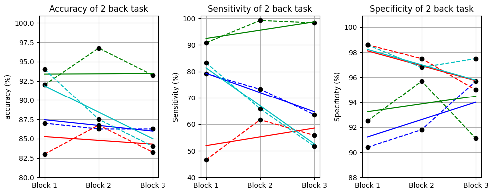

```python
# Get the fitted values
LME_data['Fitted accuracy'] = result_acc.fittedvalues
LME_data['Fitted sensitivity'] = result_sens.fittedvalues
LME_data['Fitted specificity'] = result_spec.fittedvalues

x = ['Block 1', 'Block 2', 'Block 3']
colors = ['b', 'g', 'r', 'c']

fig, (ax1, ax2, ax3) = plt.subplots(1, 3, figsize=(10, 4))

# Accuracy plot
for i, subject in enumerate(subjects):
    subject_data = LME_data[LME_data['Subject'] == subject]
    ax1.plot(subject_data['Block'], subject_data['Accuracy'], '--', color=colors[i], label='Original Data ' + subject)
    ax1.plot(subject_data['Block'], subject_data['Accuracy'], 'o', color='k')
    ax1.plot(subject_data['Block'], subject_data['Fitted accuracy'], '-', color=colors[i], label='Fitted Line ' + subject)

ax1.set_ylim(80, 100.9)
ax1.set_ylabel('accuracy (%)')
ax1.set_xticks(np.arange(1, len(x)+1), x)
ax1.grid(visible=True)
ax1.set_title('Accuracy of 2 back task')
#ax1.legend(loc='lower center')

# Sensitivity plot
for i, subject in enumerate(subjects):
    subject_data = LME_data[LME_data['Subject'] == subject]
    ax2.plot(subject_data['Block'], subject_data['Sensitivity'], '--', color=colors[i], label='Original Data ' + subject)
    ax2.plot(subject_data['Block'], subject_data['Sensitivity'], 'o', color='k')
    ax2.plot(subject_data['Block'], subject_data['Fitted sensitivity'], '-', color=colors[i], label='Fitted Line ' + subject)

ax2.set_ylim(40, 100.9)
ax2.set_ylabel('Sensitivity (%)')
ax2.set_xticks(np.arange(1, len(x)+1), x)
ax2.grid(visible=True)
ax2.set_title('Sensitivity of 2 back task')
#ax2.legend()

# Specificity plot
for i, subject in enumerate(subjects):
    subject_data = LME_data[LME_data['Subject'] == subject]
    ax3.plot(subject_data['Block'], subject_data['Specificity'], '--', color=colors[i], label='Original Data ' + subject)
    ax3.plot(subject_data['Block'], subject_data['Specificity'], 'o', color='k')
    ax3.plot(subject_data['Block'], subject_data['Fitted specificity'], '-', color=colors[i], label='Fitted Line ' + subject)

ax3.set_ylim(88, 100.9)
ax3.set_ylabel('Specificity (%)')
ax3.set_xticks(np.arange(1, len(x)+1), x)
ax3.grid(visible=True)
ax3.set_title('Specificity of 2 back task')
#ax3.legend()

plt.tight_layout()
if export:
    plt.savefig('fitted_acc_sens_spec.png')
plt.show()
```

4. Check assumptions

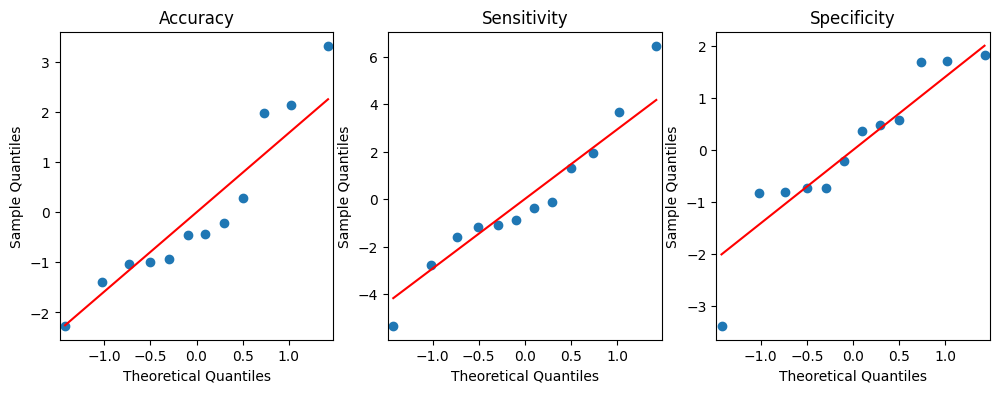

```python
# Visual inspection of normality with QQ-plot
fig, (ax1, ax2, ax3) = plt.subplots(1, 3, figsize=(12, 4))
#fig.suptitle('Q-Q PLot')

sm.qqplot(result_acc.resid, dist = stats.norm, line = 's', ax = ax1)
ax1.set_title("Accuracy")

sm.qqplot(result_sens.resid, dist = stats.norm, line = 's', ax = ax2)
ax2.set_title("Sensitivity")

sm.qqplot(result_spec.resid, dist = stats.norm, line = 's', ax = ax3)
ax3.set_title("Specificity")

plt.show()
```

```python
# Perform Shapiro-Wilk test
alpha = 0.05

SH = []
for resid in [result_acc.resid, result_sens.resid, result_spec.resid]:
    SH.append([stats.shapiro(resid)[0], stats.shapiro(resid)[1]])
SH = pd.DataFrame(SH, columns = ['statistic', 'pvalue'])
SH['Significance'] = np.where(SH['pvalue'] < alpha, 'Not normally distributed', 'Normally distributed')
SH['Metric'] = ['Accuracy', 'Sensitivity', 'Specificity']
SH = SH[['Metric', 'statistic', 'pvalue', 'Significance']]
if export:
    dfi.export(SH,"SH_acc_sens_spec.png")
SH
```

|  | Metric | statistic | pvalue | Significance |
| --- | --- | --- | --- | --- |
| 0 | Accuracy | 0.903743 | 0.177271 | Normally distributed |
| 1 | Sensitivity | 0.958451 | 0.761505 | Normally distributed |
| 2 | Specificity | 0.899519 | 0.156366 | Normally distributed |

```python
# White’s Lagrange Multiplier Test for Heteroscedasticity
WLM = []
for tuple in [(result_acc.resid, result_acc.model.exog), (result_sens.resid, result_sens.model.exog), (result_spec.resid, result_spec.model.exog)]:
    WLM.append(list(het_white(tuple[0], tuple[1])))
WLM = pd.DataFrame(WLM, columns = ["LM Statistic", "LM-Test p-value", "F-Statistic", "F-Test p-value"])
WLM['Significance LM-test'] = np.where(WLM['LM-Test p-value'] < alpha, 'Heteroscedastic', 'Homoscedastic')
WLM['Significance F-test'] = np.where(WLM['F-Test p-value'] < alpha, 'Heteroscedastisticity in the residual errors', 'No heteroscedastisticity in the residual errors')
WLM['Metric'] = ['Accuracy', 'Sensitivity', 'Specificity']
WLM = WLM[['Metric', "LM Statistic", "LM-Test p-value", 'Significance LM-test', "F-Statistic", "F-Test p-value", 'Significance F-test']]
if export:
    dfi.export(WLM,"WLM_acc_sens_spec.png")
WLM
```

|  | Metric | LM Statistic | LM-Test p-value | Significance LM-test | F-Statistic | F-Test p-value | Significance F-test |
| --- | --- | --- | --- | --- | --- | --- | --- |
| 0 | Accuracy | 2.599073 | 0.272658 | Homoscedastic | 1.244115 | 0.333390 | No heteroscedastisticity in the residual errors |
| 1 | Sensitivity | 1.817040 | 0.403120 | Homoscedastic | 0.802977 | 0.477659 | No heteroscedastisticity in the residual errors |
| 2 | Specificity | 3.978309 | 0.136811 | Homoscedastic | 2.231748 | 0.163261 | No heteroscedastisticity in the residual errors |

*LM test:* P-values are very high. So we accept the null hypothesis of the test that there is no heteroscedastisticity in the residual errors.

*F-test:* P-values confirm the null hypothesis of the test that there is no heteroscedastisticity in the residual errors.

#### Reaction times

##### Apply LME

1. Prepare the data

```python
LME_data2 = get_LME_data2(df, subjects = ['1', '2', '3', '4'])
LME_data2
```

|  | Subject | Block | RT_all | RT_correct | RT_uncorrect |
| --- | --- | --- | --- | --- | --- |
| 0 | 1 | 1 | 0.666 | 0.672 | 0.644 |
| 1 | 1 | 2 | 0.495 | 0.467 | 0.599 |
| 2 | 1 | 3 | 0.526 | 0.519 | 0.565 |
| 3 | 2 | 1 | 0.662 | 0.636 | 0.796 |
| 4 | 2 | 2 | 0.654 | 0.647 | 0.718 |
| 5 | 2 | 3 | 0.588 | 0.559 | 0.725 |
| 6 | 3 | 1 | 0.941 | 0.936 | 1.018 |
| 7 | 3 | 2 | 0.874 | 0.847 | 1.159 |
| 8 | 3 | 3 | 1.031 | 1.003 | 1.166 |
| 9 | 4 | 1 | 0.531 | 0.523 | 0.731 |
| 10 | 4 | 2 | 0.638 | 0.602 | 0.958 |
| 11 | 4 | 3 | 0.525 | 0.518 | 0.586 |

2. Fit the model

***All responses***

```python
# Fit mixed-effects model for random intercept and slope
model_all = mixedlm("RT_all ~ Block", LME_data2, groups=LME_data["Subject"], re_formula="~1+Block")
result_all = model_all.fit()
result_all.summary()
```

| Model: | MixedLM | Dependent Variable: | RT_all |
| --- | --- | --- | --- |
| No. Observations: | 12 | Method: | REML |
| No. Groups: | 4 | Scale: | 0.0040 |
| Min. group size: | 3 | Log-Likelihood: | 6.1872 |
| Max. group size: | 3 | Converged: | Yes |
| Mean group size: | 3.0 |  |  |

|  | Coef. | Std.Err. | z | P>\|z\| | [0.025 | 0.975] |
| --- | --- | --- | --- | --- | --- | --- |
| Intercept | 0.710 | 0.070 | 10.172 | 0.000 | 0.573 | 0.847 |
| Block | -0.016 | 0.030 | -0.538 | 0.591 | -0.075 | 0.043 |
| Group Var | 0.010 | 0.218 |  |  |  |  |
| Group x Block Cov | 0.004 |  |  |  |  |  |
| Block Var | 0.002 | 0.029 |  |  |  |  |

```python
if export:
    table1, table2 = result_all.summary().tables
    table1.columns = table1.iloc[0]
    table1 = table1.drop([0])
    dfi.export(table1,"all_table1.png")
    dfi.export(table2,"all_table2.png")
```

*Result:* P-value (Block) = 0.591 > alpha = 0.05

*Conclusion:* The mean slope of -0.016 is not significantly different from zero (horizontal) slope. RT of all responses does not change during the experiment.

```python
# Fit mixed-effects model for random intercept and slope
model_correct = mixedlm("RT_correct ~ Block", LME_data2, groups=LME_data["Subject"], re_formula="~1+Block")
result_correct = model_correct.fit()
result_correct.summary()
```

| Model: | MixedLM | Dependent Variable: | RT_correct |
| --- | --- | --- | --- |
| No. Observations: | 12 | Method: | REML |
| No. Groups: | 4 | Scale: | 0.0047 |
| Min. group size: | 3 | Log-Likelihood: | 5.7454 |
| Max. group size: | 3 | Converged: | Yes |
| Mean group size: | 3.0 |  |  |

|  | Coef. | Std.Err. | z | P>\|z\| | [0.025 | 0.975] |
| --- | --- | --- | --- | --- | --- | --- |
| Intercept | 0.703 | 0.074 | 9.458 | 0.000 | 0.557 | 0.848 |
| Block | -0.021 | 0.030 | -0.700 | 0.484 | -0.080 | 0.038 |
| Group Var | 0.011 | 0.175 |  |  |  |  |
| Group x Block Cov | 0.004 |  |  |  |  |  |
| Block Var | 0.001 |  |  |  |  |  |

```python
if export:
    table1, table2 = result_correct.summary().tables
    table1.columns = table1.iloc[0]
    table1 = table1.drop([0])
    dfi.export(table1,"correct_table1.png")
    dfi.export(table2,"correct_table2.png")
```

*Result:* P-value (Block) = 0.484 > alpha = 0.05

```python
# Fit mixed-effects model for random intercept and slope
model_uncorrect = mixedlm("RT_uncorrect ~ Block", LME_data2, groups=LME_data["Subject"], re_formula="~1+Block")
result_uncorrect = model_uncorrect.fit()
result_uncorrect.summary()
```

| Model: | MixedLM | Dependent Variable: | RT_uncorrect |
| --- | --- | --- | --- |
| No. Observations: | 12 | Method: | REML |
| No. Groups: | 4 | Scale: | 0.0100 |
| Min. group size: | 3 | Log-Likelihood: | 2.5278 |
| Max. group size: | 3 | Converged: | Yes |
| Mean group size: | 3.0 |  |  |

|  | Coef. | Std.Err. | z | P>\|z\| | [0.025 | 0.975] |
| --- | --- | --- | --- | --- | --- | --- |
| Intercept | 0.842 | 0.091 | 9.272 | 0.000 | 0.664 | 1.020 |
| Block | -0.018 | 0.045 | -0.410 | 0.682 | -0.106 | 0.070 |
| Group Var | 0.010 | 0.357 |  |  |  |  |
| Group x Block Cov | 0.005 |  |  |  |  |  |
| Block Var | 0.003 | 0.095 |  |  |  |  |

```python
if export:
    table1, table2 = result_uncorrect.summary().tables
    table1.columns = table1.iloc[0]
    table1 = table1.drop([0])
    dfi.export(table1,"uncorrect_table1.png")
    dfi.export(table2,"uncorrect_table2.png")
```

*Result:* P-value (Block) = 0.682 > alpha = 0.05

3. Visualize results

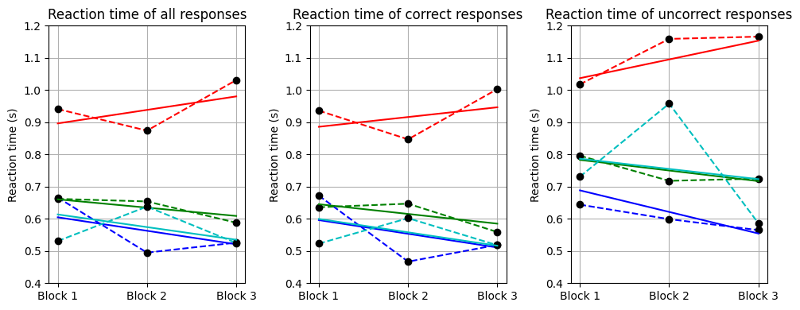

```python
# Get the fitted values
LME_data2['Fitted RT_all'] = result_all.fittedvalues
LME_data2['Fitted RT_correct'] = result_correct.fittedvalues
LME_data2['Fitted RT_uncorrect'] = result_uncorrect.fittedvalues

x = ['Block 1', 'Block 2', 'Block 3']
colors = ['b', 'g', 'r', 'c']

fig, (ax1, ax2, ax3) = plt.subplots(1, 3, figsize=(10, 4))

# Accuracy plot
for i, subject in enumerate(subjects):
    subject_data = LME_data2[LME_data2['Subject'] == subject]
    ax1.plot(subject_data['Block'], subject_data['RT_all'], '--', color=colors[i], label='Original Data ' + subject)
    ax1.plot(subject_data['Block'], subject_data['RT_all'], 'o', color='k')
    ax1.plot(subject_data['Block'], subject_data['Fitted RT_all'], '-', color=colors[i], label='Fitted Line ' + subject)

ax1.set_ylim(0.4, 1.2)
ax1.set_ylabel('Reaction time (s)')
ax1.set_xticks(np.arange(1, len(x)+1), x)
ax1.grid(visible=True)
ax1.set_title('Reaction time of all responses')
#ax1.legend(loc='lower center')

# Sensitivity plot
for i, subject in enumerate(subjects):
    subject_data = LME_data2[LME_data2['Subject'] == subject]
    ax2.plot(subject_data['Block'], subject_data['RT_correct'], '--', color=colors[i], label='Original Data ' + subject)
    ax2.plot(subject_data['Block'], subject_data['RT_correct'], 'o', color='k')
    ax2.plot(subject_data['Block'], subject_data['Fitted RT_correct'], '-', color=colors[i], label='Fitted Line ' + subject)

ax2.set_ylim(0.4, 1.2)
ax2.set_ylabel('Reaction time (s)')
ax2.set_xticks(np.arange(1, len(x)+1), x)
ax2.grid(visible=True)
ax2.set_title('Reaction time of correct responses')
#ax2.legend()

# Specificity plot
for i, subject in enumerate(subjects):
    subject_data = LME_data2[LME_data2['Subject'] == subject]
    ax3.plot(subject_data['Block'], subject_data['RT_uncorrect'], '--', color=colors[i], label='Original Data ' + subject)
    ax3.plot(subject_data['Block'], subject_data['RT_uncorrect'], 'o', color='k')
    ax3.plot(subject_data['Block'], subject_data['Fitted RT_uncorrect'], '-', color=colors[i], label='Fitted Line ' + subject)

ax3.set_ylim(0.4, 1.2)
ax3.set_ylabel('Reaction time (s)')
ax3.set_xticks(np.arange(1, len(x)+1), x)
ax3.grid(visible=True)
ax3.set_title('Reaction time of uncorrect responses')
#ax3.legend()

plt.tight_layout()
if export:
    plt.savefig('fitted_reaction_times.png')
plt.show()
```

4. Check assumptions

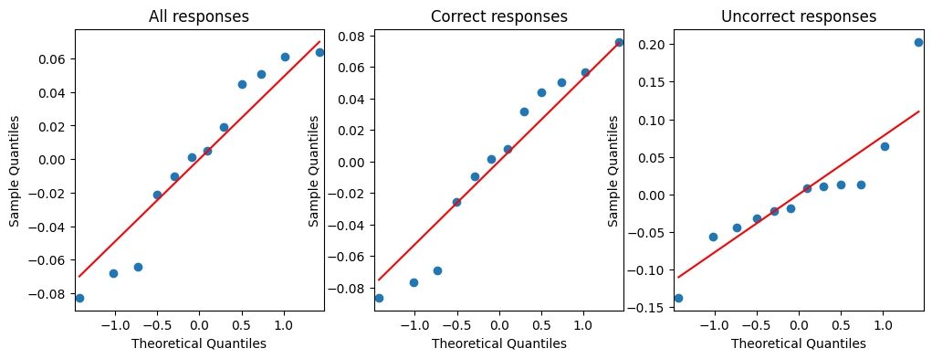

```python
# Visual inspection of normality with QQ-plot
fig, (ax1, ax2, ax3) = plt.subplots(1, 3, figsize=(12, 4))
#fig.suptitle('Q-Q PLot')

sm.qqplot(result_all.resid, dist = stats.norm, line = 's', ax = ax1)
ax1.set_title("All responses")

sm.qqplot(result_correct.resid, dist = stats.norm, line = 's', ax = ax2)
ax2.set_title("Correct responses")

sm.qqplot(result_uncorrect.resid, dist = stats.norm, line = 's', ax = ax3)
ax3.set_title("Uncorrect responses")

plt.show()
```

```python
# Perform Shapiro-Wilk test
alpha = 0.05

SH = []
for resid in [result_all.resid, result_correct.resid, result_uncorrect.resid]:
    SH.append([stats.shapiro(resid)[0], stats.shapiro(resid)[1]])
SH = pd.DataFrame(SH, columns = ['statistic', 'pvalue'])
SH['Significance'] = np.where(SH['pvalue'] < alpha, 'Not normally distributed', 'Normally distributed')
SH['Metric'] = ['All responses', 'Correct responses', 'Uncorrect responses']
SH = SH[['Metric', 'statistic', 'pvalue', 'Significance']]
if export:
    dfi.export(SH,"SH_reaction_times.png")
SH
```

|  | Metric | statistic | pvalue | Significance |
| --- | --- | --- | --- | --- |
| 0 | All responses | 0.922849 | 0.310399 | Normally distributed |
| 1 | Correct responses | 0.930860 | 0.389320 | Normally distributed |
| 2 | Uncorrect responses | 0.875933 | 0.077755 | Normally distributed |

```python
# White’s Lagrange Multiplier Test for Heteroscedasticity
WLM = []
for tuple in [(result_all.resid, result_all.model.exog), (result_correct.resid, result_correct.model.exog), (result_uncorrect.resid, result_uncorrect.model.exog)]:
    WLM.append(list(het_white(tuple[0], tuple[1])))
WLM = pd.DataFrame(WLM, columns = ["LM Statistic", "LM-Test p-value", "F-Statistic", "F-Test p-value"])
WLM['Significance LM-test'] = np.where(WLM['LM-Test p-value'] < alpha, 'Heteroscedastic', 'Homoscedastic')
WLM['Significance F-test'] = np.where(WLM['F-Test p-value'] < alpha, 'Heteroscedastisticity in the residual errors', 'No heteroscedastisticity in the residual errors')
WLM['Metric'] = ['All responses', 'Correct responses', 'Uncorrect responses']
WLM = WLM[['Metric', "LM Statistic", "LM-Test p-value", 'Significance LM-test', "F-Statistic", "F-Test p-value", 'Significance F-test']]
if export:
    dfi.export(WLM,"WLM_reaction_times.png")
WLM
```

|  | Metric | LM Statistic | LM-Test p-value | Significance LM-test | F-Statistic | F-Test p-value | Significance F-test |
| --- | --- | --- | --- | --- | --- | --- | --- |
| 0 | All responses | 3.343179 | 0.187948 | Homoscedastic | 1.737856 | 0.230037 | No heteroscedastisticity in the residual errors |
| 1 | Correct responses | 3.105253 | 0.211691 | Homoscedastic | 1.570999 | 0.259888 | No heteroscedastisticity in the residual errors |
| 2 | Uncorrect responses | 1.596861 | 0.450035 | Homoscedastic | 0.690741 | 0.525925 | No heteroscedastisticity in the residual errors |

*LM test:* P-values are very high. So we accept the null hypothesis of the test that there is no heteroscedastisticity in the residual errors.

*F-test:* P-values confirm the null hypothesis of the test that there is no heteroscedastisticity in the residual errors.

## Subjective fatigue metric

### Calculate subjective fatigue metric

```python
sfm = []
for i, subject in enumerate(subjects):
    df_subject = df[df['Subject'] == subject]
    sfm.append([df_subject['slider_2.response'][112], df_subject['slider.response'][513], df_subject['slider.response'][914], df_subject['slider.response'][1315]])
```

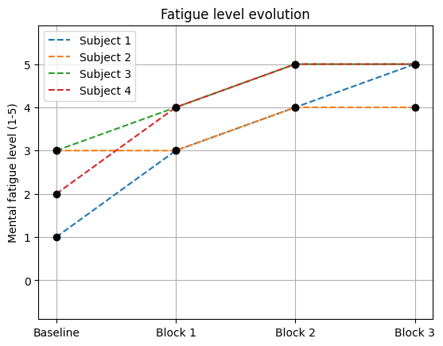

```python
x = ['Baseline', 'Block 1', 'Block 2', 'Block 3']
for i, subject in enumerate(subjects):
    plt.plot(x, sfm[i], '--', label = 'Subject ' + subject)
    plt.plot(x, sfm[i], 'o', color ='k')
plt.ylim(-0.9, 5.9)
plt.ylabel('Mental fatigue level (1-5)')
plt.grid(visible=True)
plt.title('Fatigue level evolution')
plt.legend()
if export:
    plt.savefig('sfm.png')
plt.show()
```

*Remark:*

- Subjective mental fatigue level increased during experiment

### Analyze subjective fatigue metric

##### MLE

1. Prepare data

```python
# Prepare data
LME_data3 = get_LME_data3(df, subjects = ['1', '2', '3', '4'])
LME_data3
```

|  | Subject | Block | Score |
| --- | --- | --- | --- |
| 0 | 1 | 0 | 1.0 |
| 1 | 1 | 1 | 3.0 |
| 2 | 1 | 2 | 4.0 |
| 3 | 1 | 3 | 5.0 |
| 4 | 2 | 0 | 3.0 |
| 5 | 2 | 1 | 3.0 |
| 6 | 2 | 2 | 4.0 |
| 7 | 2 | 3 | 4.0 |
| 8 | 3 | 0 | 3.0 |
| 9 | 3 | 1 | 4.0 |
| 10 | 3 | 2 | 5.0 |
| 11 | 3 | 3 | 5.0 |
| 12 | 4 | 0 | 2.0 |
| 13 | 4 | 1 | 4.0 |
| 14 | 4 | 2 | 5.0 |
| 15 | 4 | 3 | 5.0 |

2. Fit the model

```python
# Fit mixed-effects model for random intercept and slope
model_sfm = mixedlm("Score ~ Block", LME_data3, groups=LME_data3["Subject"], re_formula="~1+Block")
result_sfm = model_sfm.fit()
result_sfm.summary()
```

| Model: | MixedLM | Dependent Variable: | Score |
| --- | --- | --- | --- |
| No. Observations: | 16 | Method: | REML |
| No. Groups: | 4 | Scale: | 0.2250 |
| Min. group size: | 4 | Log-Likelihood: | -15.9526 |
| Max. group size: | 4 | Converged: | Yes |
| Mean group size: | 4.0 |  |  |

|  | Coef. | Std.Err. | z | P>\|z\| | [0.025 | 0.975] |
| --- | --- | --- | --- | --- | --- | --- |
| Intercept | 2.475 | 0.417 | 5.934 | 0.000 | 1.658 | 3.292 |
| Block | 0.850 | 0.194 | 4.389 | 0.000 | 0.470 | 1.230 |
| Group Var | 0.538 | 1.405 |  |  |  |  |
| Group x Block Cov | -0.208 | 0.592 |  |  |  |  |
| Block Var | 0.105 | 0.303 |  |  |  |  |

```python
if export:
    table1, table2 = result_sfm.summary().tables
    table1.columns = table1.iloc[0]
    table1 = table1.drop([0])
    dfi.export(table1,"sfm_table1.png")
    dfi.export(table2,"sfm_table2.png")
```

*Result:* P-value (Block) = 0.00 < alpha = 0.05

*Conclusion:* The mean slope of 0.850 is significantly different from zero (horizontal) slope. The subjective mental fatigue score does change during the experiment.

3. Visualize the result

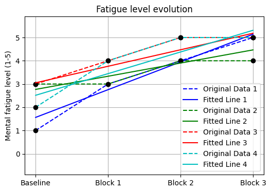

```python
# Get the fitted values
LME_data3['Fitted score'] = result_sfm.fittedvalues

x = ['Baseline', 'Block 1', 'Block 2', 'Block 3']
colors = ['b', 'g', 'r', 'c']

plt.figure(figsize=(6, 4))

# Accuracy plot
for i, subject in enumerate(subjects):
    subject_data = LME_data3[LME_data3['Subject'] == subject]
    plt.plot(subject_data['Block'], subject_data['Score'], '--', color=colors[i], label='Original Data ' + subject)
    plt.plot(subject_data['Block'], subject_data['Score'], 'o', color='k')
    plt.plot(subject_data['Block'], subject_data['Fitted score'], '-', color=colors[i], label='Fitted Line ' + subject)

plt.ylim(-0.9, 5.9)
plt.ylabel('Mental fatigue level (1-5)')
plt.xticks(np.arange(len(x)), x)
plt.grid(visible=True)
plt.title('Fatigue level evolution')
if export:
    plt.savefig('sfm_fitted.png')
plt.legend()
plt.show()
```

4. Check assumptions

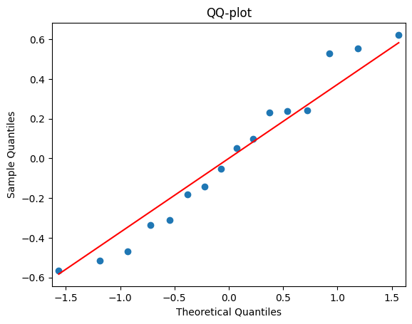

```python
# Visual inspection of normality with QQ-plot

sm.qqplot(result_sfm.resid, dist = stats.norm, line = 's')
plt.title('QQ-plot')

plt.show()
```

```python
# Perform Shapiro-Wilk test
alpha = 0.05

SH = {'statistic': stats.shapiro(result_sfm.resid)[0], 'pvalue' : stats.shapiro(result_sfm.resid)[1]}
SH['Significance'] = 'Not normally distributed' if SH['pvalue'] < alpha else  'Normally distributed'
SH
```

```
{'statistic': 0.9491629004478455,
 'pvalue': 0.47654327750205994,
 'Significance': 'Normally distributed'}
```

```python
# White’s Lagrange Multiplier Test for Heteroscedasticity
WLM ={}
for i, name in enumerate(["LM Statistic", "LM-Test p-value", "F-Statistic", "F-Test p-value"]):
    WLM[name] = het_white(result_sfm.resid, result_sfm.model.exog)[i]

WLM['Significance LM-test'] = 'Heteroscedastic' if WLM['LM-Test p-value'] < alpha else 'Homoscedastic'
WLM['Significance F-test'] = 'Heteroscedastisticity in the residual errors'if WLM['F-Test p-value'] < alpha else 'No heteroscedastisticity in the residual errors'
WLM
```

```
{'LM Statistic': 0.5011976110898679,
 'LM-Test p-value': 0.7783345724427883,
 'F-Statistic': 0.2101958841939421,
 'F-Test p-value': 0.8131263394309685,
 'Significance LM-test': 'Homoscedastic',
 'Significance F-test': 'No heteroscedastisticity in the residual errors'}
```